# TrabajoFinal

Alejandro Ramos Usaj, Agostina Sacson y Iair Embon

2022-07-25

```r
library(tidyverse)
```

Cargo los datos

```r
# voy a la carpeta del proyecto
root <- rprojroot::is_rstudio_project
basename(getwd())
```

```
## [1] "Entrega_Final"
```

```r
# load the function to get the df list
# source(root$find_file("Entrega_Final/df_total_filtered.Rda")) ## me tira un error aca, no se poque lo voy a esta resolviendo

load("./df_total_filtered.Rda")
```

Lo exploro

```r
str(df_total)
```

```
## 'data.frame':    23481 obs. of  53 variables:
##  $ Participant                 : num  1 1 1 1 1 1 1 1 1 1 ...
##  $ gender                      : chr  "Masculino" "Masculino" "Masculino" "Masculino" ...
##  $ RelyOn                      : chr  "Pueden contar con mis respuestas, participé del experimento a consciencia e intenté responder honestamente." "Pueden contar con mis respuestas, participé del experimento a consciencia e intenté responder honestamente." "Pueden contar con mis respuestas, part…
##  $ Problems                    : chr  "ok" "ok" "ok" "ok" ...
##  $ Anhedonia                   : num  0.75 0.75 0.75 0.75 0.75 0.75 0.75 0.75 0.75 0.75 ...
##  $ Anxiousness                 : num  2.22 2.22 2.22 2.22 2.22 ...
##  $ AttentionSeeking            : num  2.25 2.25 2.25 2.25 2.25 2.25 2.25 2.25 2.25 2.25 ...
##  $ Callousness                 : num  0.857 0.857 0.857 0.857 0.857 ...
##  $ Deceitfulness               : num  1.5 1.5 1.5 1.5 1.5 1.5 1.5 1.5 1.5 1.5 ...
##  $ Depressivity                : num  0.929 0.929 0.929 0.929 0.929 ...
##  $ Distractivility             : num  2.33 2.33 2.33 2.33 2.33 ...
##  $ Excentricity                : num  2.31 2.31 2.31 2.31 2.31 ...
##  $ EmotionalLability           : num  2 2 2 2 2 2 2 2 2 2 ...
##  $ Grandiosity                 : num  1.67 1.67 1.67 1.67 1.67 ...
```

[output cut: 39 more lines]

Veo la cantidad de participantes

```r
print(length(unique(df_total$Participant)))
```

```
## [1] 224
```

Exploro la variable de interes (Confianza)

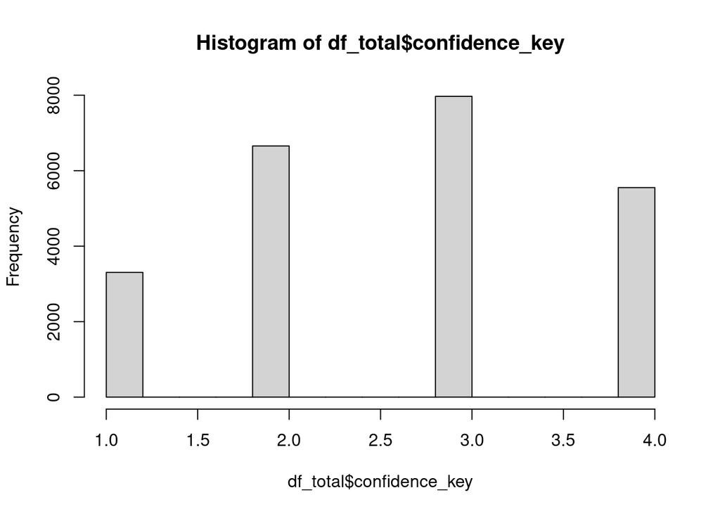

```r
hist(df_total$confidence_key)
```

Convierto el df por trials en un df por participantes

```r
d <- df_total %>%
  select(!c(RelyOn,
            Problems,
            ConfKey1,
            ConfKey2,
            ConfKey3,
            ConfKey4,
            discrimination_is_correct,
            confidence_key,
            trials,
            PointDifference,
            ReacTime_DiscTask,
            ReacTime_ConfTask)) %>%
  distinct(Participant,.keep_all = TRUE)
```

Exploro la otra variable de interes (metacognicion)

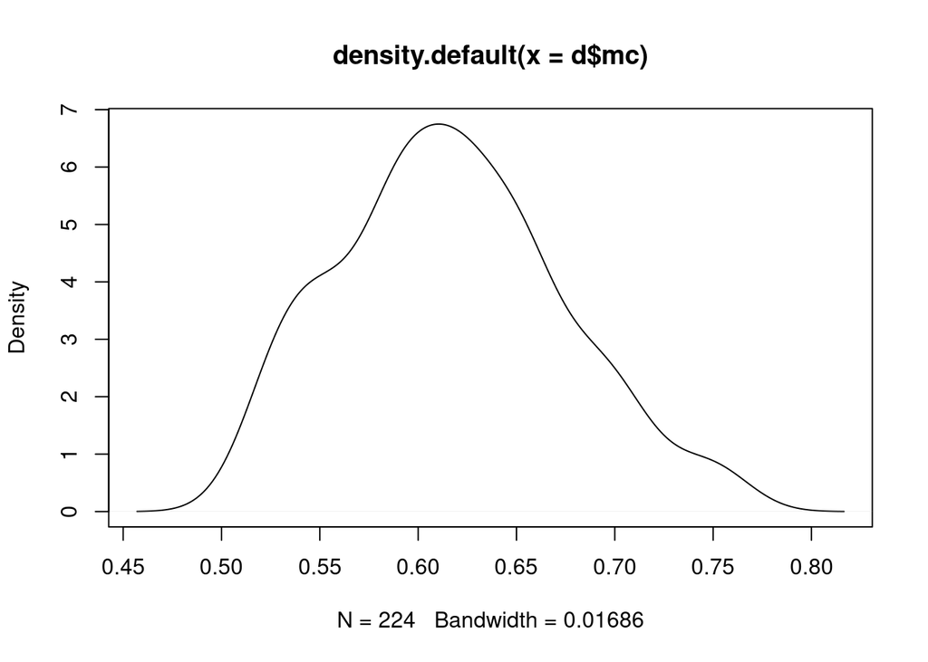

```r
plot(density(d$mc))
```

Exploro la confianza promedio de cada participante en base al desempeño en la tarea. Por el procedimiento en escalera deberian tener una precision (proporcion de respuestas correctas) del 0.72.

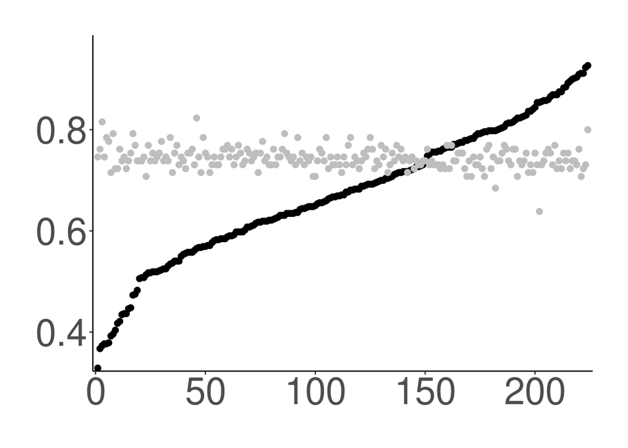

```r
d %>%  ## no me estarian saliendo las leyendas, despues reviso
  select(ConfMean,PC,Participant) %>%
  # normalizo el promedio de confianza por sujeto para que este en una escala similar a la del desempeno
  mutate(ConfMean = ConfMean/4, nr = row_number()) %>%
  arrange(ConfMean) %>%
  mutate(nr = row_number()) %>%
  ggplot(aes(x= nr)) +
  geom_point(aes(y=ConfMean), size = 2, color = "black") +
  geom_point(aes(y=PC), size = 2, color = "grey")+
  scale_x_continuous(expand = expansion(mult = c(0.01, 0.01))) +
  scale_y_continuous(expand = expansion(mult = c(0.01, 0.1))) +
  theme(axis.line = element_line(colour = "black"),
        panel.grid.major = element_blank(),
        panel.grid.minor = element_blank(),
        panel.border = element_blank(),
        plot.margin = margin(1, 1,1, 1, "cm"),
        legend.text =  element_text(size = 25),
        legend.position = c(0.7, 0.2),
        legend.background = element_blank(),
        legend.key = element_blank(),
        legend.title = element_blank(),
        panel.background = element_blank(),
        axis.text.x = element_text(size = 30),
        axis.text.y = element_text(size = 30),
        axis.title.x = element_blank(),
        axis.title.y = element_blank())
```

Con esto se puede medir calibracion. Si la media de la confianza esta por encima de 0.72 entonces implica sobreconfianza, y si esta por debajo implica bajaconfianza.

Agregamos una variable que va a decir si es overconfidence y underconfidence para cada participante. 1 si es overconfidence.

```r
d <- d %>%
  mutate(ConfMean.norm = ConfMean/4,
         overconfidence = ifelse(ConfMean.norm > 0.72, 1, 0))
# veo cuantos hay
d %>%
  summarise(n= sum(overconfidence))
```

```
##    n
## 1 81
```

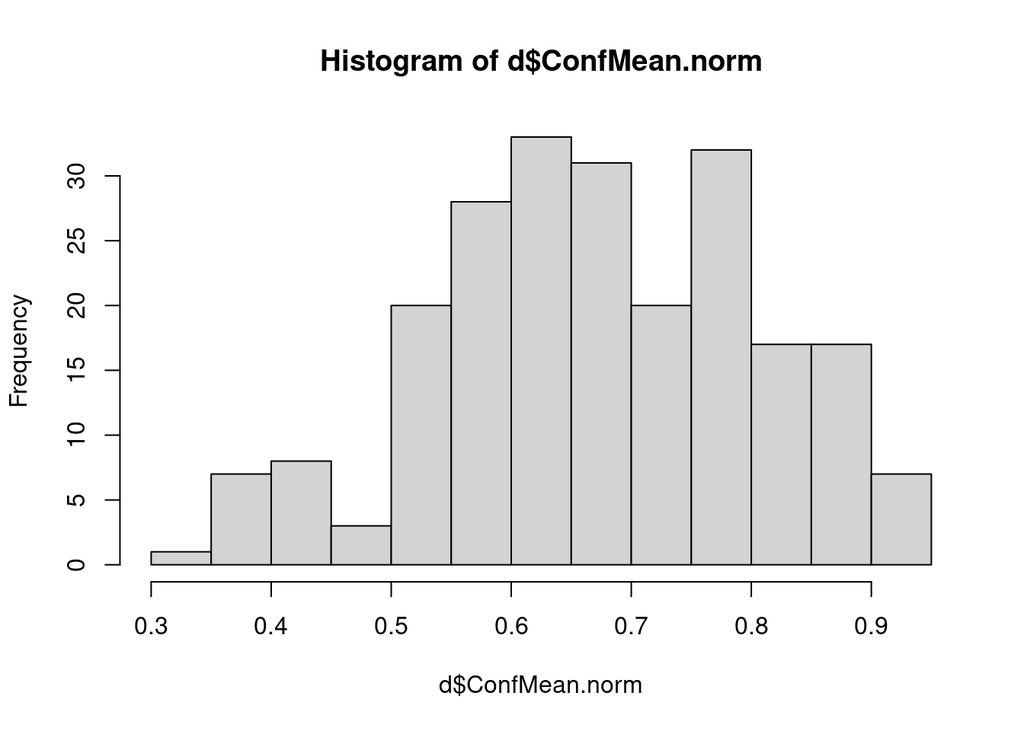

```r
# hay 81 participantes con alta confianza, lo que nos da 143 con baja confianza

hist(d$ConfMean.norm)
```

Preproceso la varible genero

```r
d$gender <- ifelse(d$gender == "Masculino",1,0)
```

Corremos una regresion logistica para predecir underconfidence y overconfidence con los dominios de los rasgos disfuncionales de la personalidad

```r
model <- glm(overconfidence ~ DomainAntagonism +
               DomainDetachment +
               DomainDisinhibition +
               DomainNegativeAffect +
               DomainPsychoticism,
             family=binomial(link='logit'),
             data=d)
summary(model)
```

```
##
## Call:
## glm(formula = overconfidence ~ DomainAntagonism + DomainDetachment +
##     DomainDisinhibition + DomainNegativeAffect + DomainPsychoticism,
##     family = binomial(link = "logit"), data = d)
##
## Deviance Residuals:
##     Min       1Q   Median       3Q      Max
## -1.3014  -0.9494  -0.8563   1.3432   1.6834
##
## Coefficients:
##                      Estimate Std. Error z value Pr(>|z|)
## (Intercept)           -0.7428     0.4156  -1.787   0.0739 .
## DomainAntagonism       0.1432     0.3079   0.465   0.6418
## DomainDetachment      -0.1415     0.3018  -0.469   0.6392
## DomainDisinhibition    0.6512     0.3420   1.904   0.0569 .
## DomainNegativeAffect  -0.1473     0.3042  -0.484   0.6283
## DomainPsychoticism    -0.2787     0.3751  -0.743   0.4576
## ---
## Signif. codes:  0 '***' 0.001 '**' 0.01 '*' 0.05 '.' 0.1 ' ' 1
##
## (Dispersion parameter for binomial family taken to be 1)
##
##     Null deviance: 293.14  on 223  degrees of freedom
## Residual deviance: 288.97  on 218  degrees of freedom
## AIC: 300.97
##
## Number of Fisher Scoring iterations: 4
```

Corro otro modelo logistico pero esta vez controlo por edad y genero

```r
model2 <- glm(overconfidence ~ DomainAntagonism +
               DomainDetachment +
               DomainDisinhibition +
               DomainNegativeAffect +
               DomainPsychoticism +
               gender +
               age,
             family=binomial(link='logit'),
             data=d)
summary(model2)
```

```
##
## Call:
## glm(formula = overconfidence ~ DomainAntagonism + DomainDetachment +
##     DomainDisinhibition + DomainNegativeAffect + DomainPsychoticism +
##     gender + age, family = binomial(link = "logit"), data = d)
##
## Deviance Residuals:
##     Min       1Q   Median       3Q      Max
## -1.2653  -0.9618  -0.8161   1.3079   1.7629
##
## Coefficients:
##                      Estimate Std. Error z value Pr(>|z|)
## (Intercept)          -1.07208    0.73123  -1.466   0.1426
## DomainAntagonism      0.26423    0.31992   0.826   0.4088
## DomainDetachment     -0.18206    0.30503  -0.597   0.5506
## DomainDisinhibition   0.67923    0.34544   1.966   0.0493 *
## DomainNegativeAffect -0.15547    0.31866  -0.488   0.6256
## DomainPsychoticism   -0.26459    0.37589  -0.704   0.4815
## gender               -0.47666    0.33320  -1.431   0.1526
## age                   0.01386    0.01652   0.839   0.4015
## ---
## Signif. codes:  0 '***' 0.001 '**' 0.01 '*' 0.05 '.' 0.1 ' ' 1
##
## (Dispersion parameter for binomial family taken to be 1)
##
##     Null deviance: 293.14  on 223  degrees of freedom
## Residual deviance: 286.17  on 216  degrees of freedom
## AIC: 302.17
##
## Number of Fisher Scoring iterations: 4
```

#Regresion logistica usando metodos de regularizaciones

Por otro lado, es importante para estas regularizaciones, elegir un lambda adecuado, el cual se suele elegir mediante algun metodo de cross validation. Usualmente, en los trabajos que revisamos, usan 10 fold corss validation, aunque por la poca cantidad de datos usaremos leave one out cross validation (LOOCV). Para eso crearemos nuestra propia funcion de LOOCV

Cargo la libreria

```r
library(glmnet)
```

Creo una funcion para realizar un LOOCV y elegir asi el valor de lambda optimo.

```r
####

LOOCV.fun.glmnet <- function(df, alpha.dado){
  # creo una secuencua de posibles lambdas
  posibles_lambdas <- seq(0.0000001, 0.01, length.out = 1000)

  # creo una matriz en donde se van a ir guardando los errores de cada lambda y cada vez que hago LOOCV
  matriz.errores <- matrix(data=NA,nrow= nrow(df),
                           ncol= length(posibles_lambdas))

  for (j in 1:nrow(df)){
    # datos de entrenamiento (todos menos 1)
    train <- d.regre.regul.facetas %>%
      filter(Participant != df$Participant[j])

    # agarro el dato que quedo para el testeo
    test  <- anti_join(df, train, by = 'Participant')

    # Guardo las observaciones de overconfidence en entrenamiento y testeo (para entrenar el modelo y testearlo)
    y.train <- train$overconfidence
    y.test <- test$overconfidence

    # ahora les saco overconfidence y Participant (ya que no tienen que ir como predictores)
    train <- train %>% select(!c(overconfidence,Participant))
    test <- test %>% select(!c(overconfidence,Participant))

    # transformo en matrix
    train.m <- train %>% data.matrix()
    test.m <- test %>% data.matrix()

    # corro el modelo con los datos de entrenamiento
    modelo <- glmnet(train.m, y.train, family = "binomial",
                            alpha = alpha.dado , lambda = posibles_lambdas)

    # hago prediccion sobre la data de testeo
    probabilities <- modelo %>% predict(newx = test.m, type = "response")
    predicted.classes <- ifelse(probabilities > 0.5, 1, 0)
    # Model accuracy
    matriz.errores[j,] <- predicted.classes == y.test
  }

  # saco los root mean squared errors para cada lambda
  lambda.RMSE <- sqrt(((rowSums(matriz.errores))**2)/nrow(df))

  return(matriz.errores)
  }


  ###### me da rarisimo, pruebo si el modelo esta mal o mi funcion esta mal usando funciones de cv, para j <- 1

# cvfit <- cv.glmnet(spam_train, spam_y_train, family = "binomial",
#                           alpha = 1)
#
# plot(cvfit)
# cvfit$lambda.min
# coef(cvfit, s = "lambda.min")

# no coincide ni en pedo, esta mal mi funcion asumo
```

#Para facetas

Primero saco algunas variables que no van a ser necesarias.

```r
# saco las variables que no me interesan para esta parte de facetas
d.regre.regul.facetas <- d %>%
  select(!c(DomainNegativeAffect,
            DomainDetachment,
            DomainAntagonism,
            DomainDisinhibition,
            DomainPsychoticism,
            PC,
            ConfMean,
            ConfSD,
            ReacTimeMean_DiscTask,
            ReacTimeSD_DiscTask,
            ReacTimeMean_ConfTask,
            ReacTimeSD_ConfTask,
            mc,
            ConfMean.norm))
```

Ajusto una regresion con penalizacion Ridge.

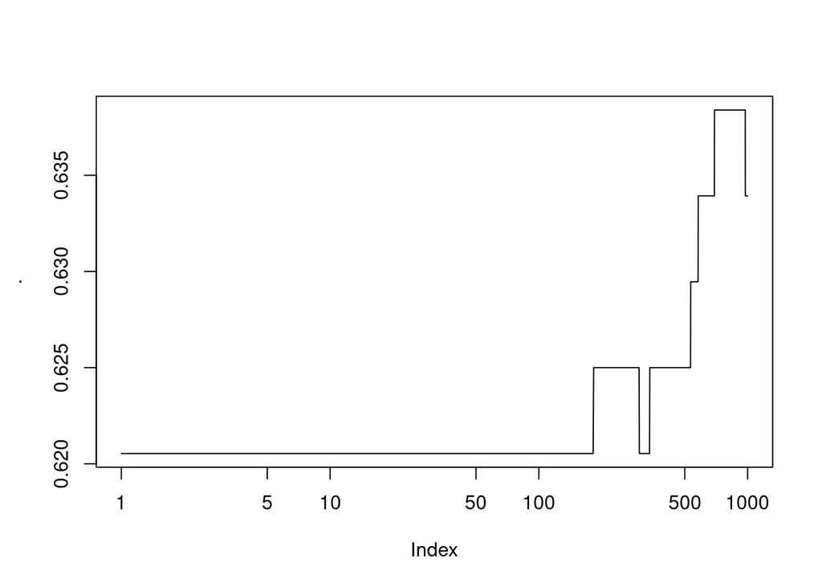

```r
lambdaOptimo_facetas_ridge <- LOOCV.fun.glmnet(d.regre.regul.facetas, alpha.dado = 0)
lambdaOptimo_facetas_ridge %>% apply(2, mean) %>% plot(type ='l', log = 'x')
```

Ajusto una regresion penalizacion de tipo Lasoo

```r
lambdaOptimo_facetas_lasso <- LOOCV.fun.glmnet(d.regre.regul.facetas, alpha.dado = 1)
```

Ajusto una Elastic Net

```r
lambdaOptimo_facetas_elastic <- LOOCV.fun.glmnet(d.regre.regul.facetas, alpha.dado = 0.5)
```

# Dominios

Armo un vector con los nombres de las columnas que contienen las variables de interes para el caso de los dominios.

```r
domain_columns <- colnames(d)[str_detect(colnames(d), pattern = 'Domain')]
```

Genero un vector con las formulas de todos los posibles modelos que pueden generarse a partir de los 5 dominios a utilizar como covariadas. La cantidad total de modelos posibles es $\sum_{k = 1}^n\frac{n!}{k!(n-k)!}$ que para este caso nos da 31.

```r
mejor_subconjunto <- sapply(
  1:5, function(x) combn(domain_columns, x, simplify = F) %>%
                 lapply(function(y) str_flatten(y, ' + ')) %>%
                 unlist()
       )  %>% unlist() %>%
  sapply(
    function(x) paste0('overconfidence ~ ', x)
  ) %>% unname()
```

Generamos dos vectores, una que contenga las formulas de un modelo simple (de un solo predictor) y otro que contenga la formula del modelo completo (con todos los predictores).

```r
formula_dominio_simple <- mejor_subconjunto[1:5]
formula_dominio_completa <- mejor_subconjunto[length(mejor_subconjunto)]
```

```r
set.seed(1234)
bootstrap_dominio <- sapply(
  c(formula_dominio_simple,formula_dominio_completa),
  function(x) replicate(10,
  glm(as.formula(x), family = binomial(link = 'logit'),
      data = slice_sample(d, n =nrow(d), replace = T)
      )$coeff
) %>%
  apply(
    1,
    FUN = function(x.row) c(media = mean(x.row),
                            quantile(x.row, c(0.025,0.975))
                            )
    )
) %>% lapply(as.data.frame) %>% bind_rows() %>%
  mutate(
    tipo_modelo = rep(
      c('simple','completo'), c(3*5,3)
      )
         ) %>%
  rownames_to_column(var = 'tipo_medicion') %>%
  mutate(tipo_medicion = str_replace(tipo_medicion, 'media\\d|\\...\\d+','')) %>%
  pivot_longer(!starts_with('tipo'), names_to = 'coeficiente', values_to = 'estimacion') %>%
  drop_na() %>%
  filter(coeficiente != '(Intercept)') %>%
  pivot_wider(names_from = tipo_medicion, values_from = estimacion)
```

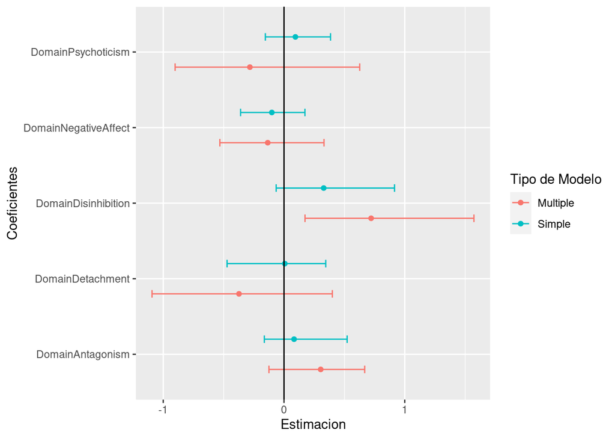

```r
bootstrap_dominio %>%
  ggplot(
    aes(x = coeficiente, y = media, color = tipo_modelo, ymin = `2.5%`, ymax = `97.5%`)
  ) +
  geom_point(
    position = position_dodge(.8)
  ) +
  geom_errorbar(
    width = .2,
    position = position_dodge(.8)
  ) +
  geom_hline(yintercept = 0) +
  coord_flip() +
  ylab('Estimacion') + xlab('Coeficientes') +
  scale_color_discrete('Tipo de Modelo', labels = c('Multiple', 'Simple'))
```

Evaluar un ajuste polinomial para la regresion logistica generando una grilla de posibles valores para el grado del polinomio que vaya de 1 a 15 (con intervalos de 1) y ajustar el modelo usando la funcion `poly`. Para cada grado posible del polinomio utilizar un procedimiento leave-one-out para calcular el accuracy y elegir asi el grado optimo del polinomio a utilizar.

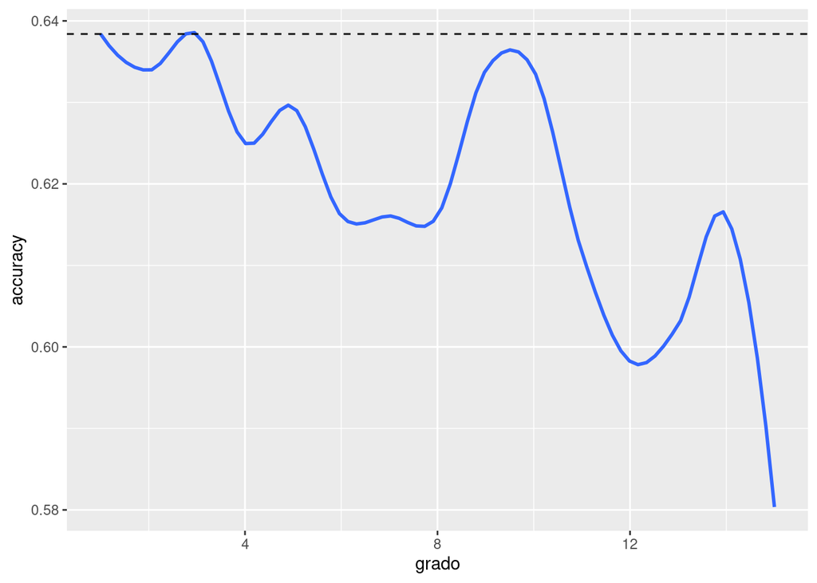

```r
grilla_grado <- expand.grid(indice = 1:nrow(d), grado = 1:15)

spam <- grilla_grado %>% mutate(
  probabilidad = grilla_grado %>%
    pmap(
      ~ glm(overconfidence ~ poly(DomainDisinhibition, .y), family = binomial(link = 'logit'),
            data = d[-.x, ]
            ) %>%
        predict(d[.x, ], type = 'response')
      ) %>%
    unlist(),
  prediccion = ifelse(probabilidad > 0.5, 1, 0),
  acierto = prediccion == d[indice, 'overconfidence']
  ) %>% group_by(grado) %>% summarise(accuracy = mean(acierto))

spam %>%
  ggplot(
    aes(x = grado, y = accuracy)
  ) + geom_smooth(span = 0.3) +
  geom_hline(
    yintercept = d %>% count(overconfidence) %>% mutate(n = n/sum(n)) %>% pull(n) %>% max(),
    linetype = 'dashed'
  )
```

Utilizando el vector `mejor_subconjunto` emplear el procedimiento leave-one-out para elegir el modelo con mejor capacidad predictiva de todos los posibles.

```r
predicciones_mejor_subconjunto <- pmap(
  expand.grid(1:nrow(d), mejor_subconjunto) %>% mutate(Var2 = as.character(Var2)),
  ~ glm(
      as.formula(.y), family = binomial(link = 'logit'), data = d, subset = -.x
    ) %>% predict(d[.x, ], type = 'response')
) %>%
  unlist()

resultado_mejor_subconjunto <- expand.grid(1:nrow(d), mejor_subconjunto) %>%
  mutate(pred = predicciones_mejor_subconjunto,
         respuesta = ifelse(pred > 0.5, 1, 0),
         acierto = as.numeric(respuesta == d[Var1, 'overconfidence'])) %>%
  ggplot(
  aes(x = Var2, y = acierto)
) +
  stat_summary(geom = 'pointrange') +
  coord_flip() +
  theme(axis.text.y = element_text(size = 5))
```